# Making better graphs: publication ready plots in ggplot

Holly Embke

# ‘ggplot2’ package makes visualizing data easy!

- ggplot is based on the ‘Grammar of Graphics’ where you begin with a blank space and add layers individually to create your figure
- To create your figure, your need 3 components: + Dataset + Coordinate system + Geoms — visual marks that represent data points

## ‘geoms’ – the layers

- Geoms are the layers that represent data points that you add to the plot space
- Geom examples include: + points (`geom_point', for scatter plots, dot plots, etc.) + lines (`geom_line’, for time series, trend lines, etc.) + boxplot (`geom_boxplot’) + smooths (‘geom_smooth’, for adding regression lines, etc.)
- You can add a geom to a plot using the ‘+’ operator
- Note that the order in which you add layers matters! This is the order in which they will be displayed in the plot

## aesthetics ‘aes’ control how layers/geoms look

- aes examples include: + position (i.e., on the x and y axes) + color (“outside” color) + fill (“inside” color) + shape (of points) + linetype + size
- Aesthetic mappings are set within geoms with the `aes()’ function

## Other common visual elements – labels & theme

- Axis and main figure labels can be added easily in ggplot: + Labs(x=“X axis”, y=“Y axis”, title=“Main Title”)
- The ‘theme’ of the plot controls many of the plot characteristics, including: + Size of axis titles and labels (‘axis.title’ and ‘axis.text’) + Legend position (‘legend.position’) + Plot background (‘panel.background’)

## Useful ggplot2 references!

- Cheatsheets: + https://resources.rstudio.com/rstudio-developed/data-transformation (dplyr and tidyr) + https://rstudio.com/wp-content/uploads/2015/03/ggplot2-cheatsheet.pdf (ggplot)
- Tutorials: + http://r-statistics.co/ggplot2-Tutorial-With-R.html#1.%20The%20Setup + http://t-redactyl.io/blog/2015/12/creating-plots-in-r-using-ggplot2-part-1-line-plots.html + http://tutorials.iq.harvard.edu/R/Rgraphics/Rgraphics.html + https://cedricscherer.netlify.com/2019/08/05/a-ggplot2-tutorial-for-beautiful-plotting-in-r/#toc + https://evamaerey.github.io/ggplot_flipbook/ggplot_flipbook_xaringan.html#1 + https://waterdata.usgs.gov/blog/boxplots/
- ggplot2 reference guide: https://ggplot2.tidyverse.org/reference/
- Color palettes: + http://colorbrewer2.org/ + https://rstudio-pubs-static.s3.amazonaws.com/3486_79191ad32cf74955b4502b8530aad627.html

# Data visualization examples using ggplot2

#### load ggplot2 package

```r
library(ggplot2)
```

### Linear models of species-specific harvest over time - example of stat_summary using geom=‘pointrange’

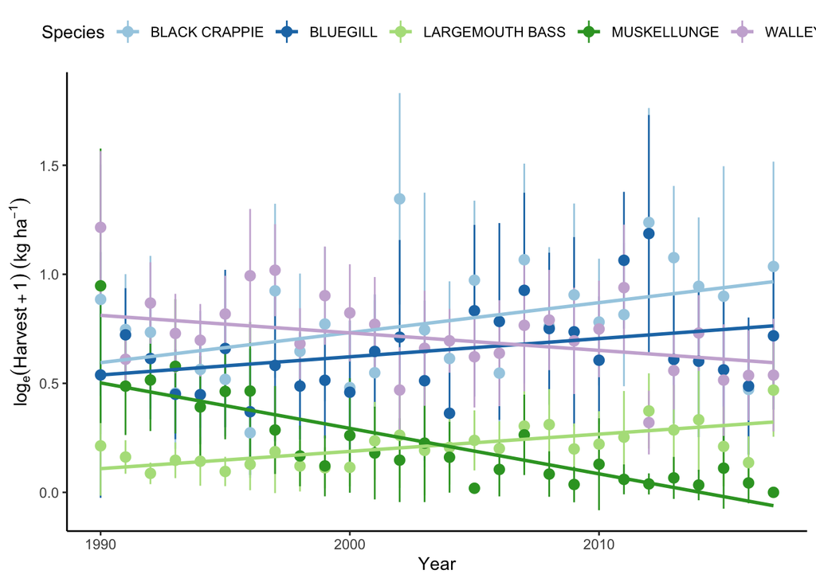

```r
sig.sp = read.csv('linear_models_species_data_plot1.csv',stringsAsFactors = F)

ggplot(sig.sp, aes(x=year, y=log.harv.kg.ha, color=species))+
  stat_summary(fun.data = mean_cl_normal, geom = "pointrange")+
  geom_smooth(method='lm',se=F,aes(group=species))+
  scale_color_manual(breaks = c('BLACK CRAPPIE', 'BLUEGILL',"LARGEMOUTH BASS",'MUSKELLUNGE','WALLEYE'),
                     values=c('#a6cee3','#1f78b4','#b2df8a','#33a02c',"#cab2d6"))+
  scale_y_continuous(name=expression(log[e]*(Harvest+1)~(kg~ha^{-1})))+
  xlab("Year")+
  labs(color='Species')+
  theme_classic()+
  theme(legend.position = 'top')
```

### Paneled species-specific trends of harvest over time - example of ‘faceting’

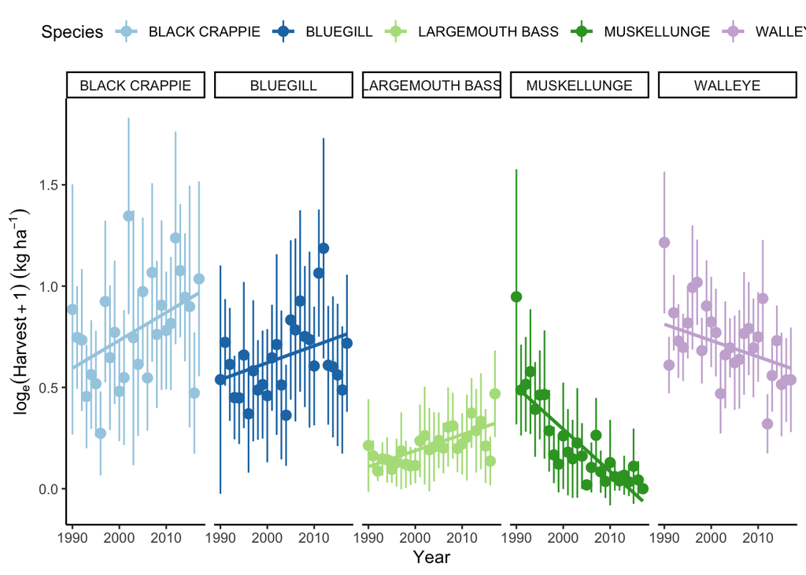

```r
ggplot(sig.sp, aes(year, log.harv.kg.ha, color=species))+
  stat_summary(fun.data = mean_cl_normal, geom = "pointrange")+
  geom_smooth(method='lm',se=F,aes(group=species))+
  facet_grid(~species)+
  scale_color_manual(breaks = c('BLACK CRAPPIE', 'BLUEGILL',"LARGEMOUTH BASS",'MUSKELLUNGE','WALLEYE'),
                     values=c('#a6cee3','#1f78b4','#b2df8a','#33a02c',"#cab2d6"))+
  scale_y_continuous(name=expression(log[e]*(Harvest+1)~(kg~ha^{-1})))+
  xlab("Year")+
  labs(color='Species')+
  theme_classic()+
  theme(legend.position = 'top')
```

### Species-specific proportion of annual harvest - example of different ‘geom’, complex color , and temporal trends

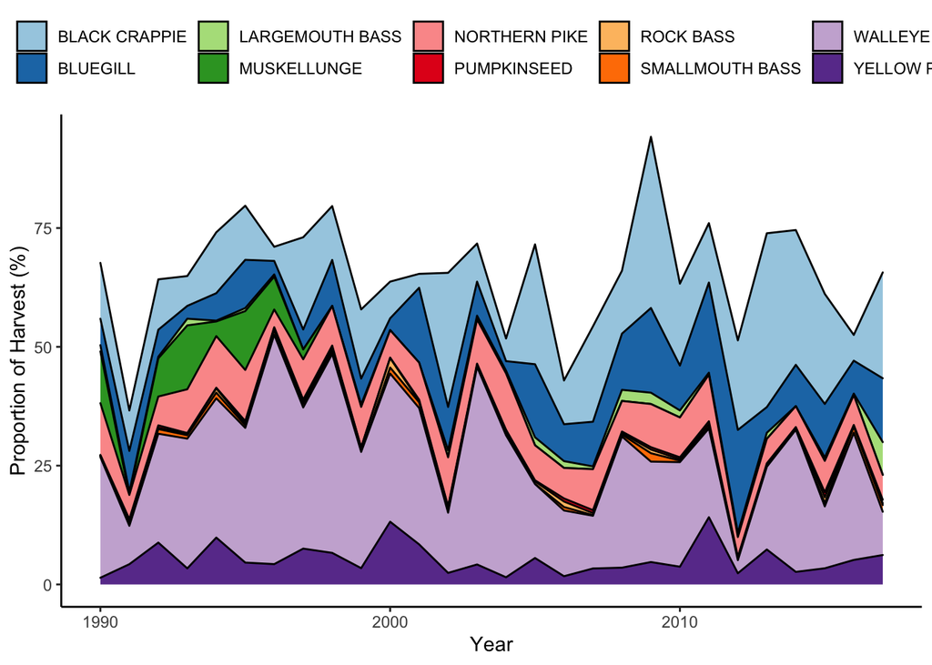

```r
prop.harv = read.csv('prop_harv_species_data_plot3.csv',stringsAsFactors = F)

ggplot(prop.harv, aes(x=year, y=(med.prop.harv*100), fill=species))+
  geom_area(color="black")+
  scale_fill_brewer(palette='Paired')+
  xlab("Year")+
  ylab("Proportion of Harvest (%)")+
  labs(fill=' ')+
  theme_classic()+
  theme(legend.position='top')
```

### Tiled heat map of species harvest - example of different ‘geom’, layered elements, and continuous color scale

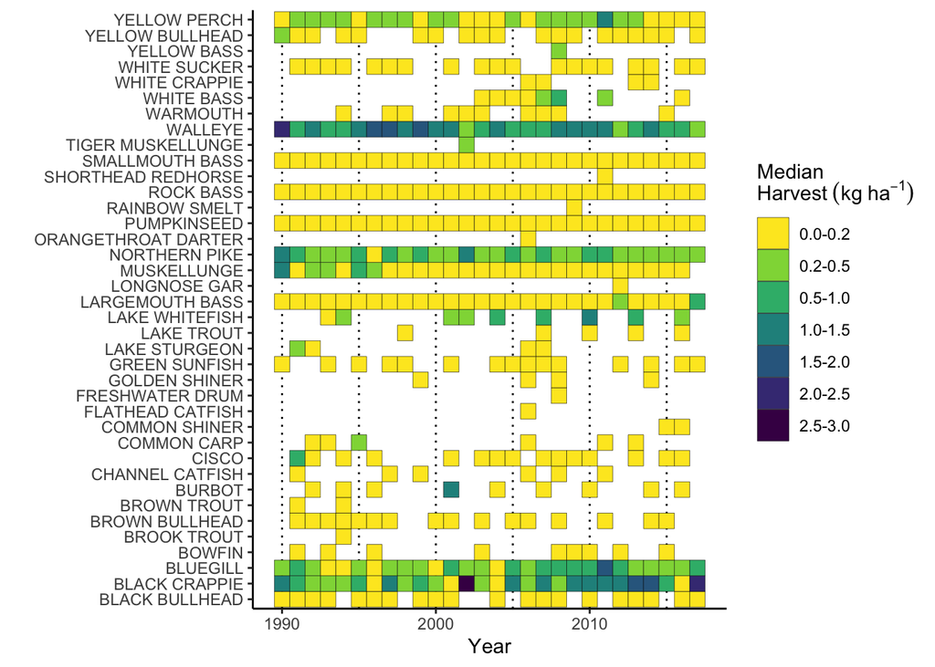

```r
tile = read.csv('tile_species_data_plot4.csv',stringsAsFactors = F)

ggplot(tile, aes(x=year,y=species,fill=as.factor(med.h.bin)))+
  geom_vline(xintercept = 1990, linetype='dotted')+
  geom_vline(xintercept = 1995, linetype='dotted')+
  geom_vline(xintercept = 2000, linetype='dotted')+
  geom_vline(xintercept = 2005, linetype='dotted')+
  geom_vline(xintercept = 2010, linetype='dotted')+
  geom_vline(xintercept = 2015, linetype='dotted')+
  geom_tile(size=0.1,na.rm=T,colour = "black")+
  scale_fill_viridis_d(direction=-1,
                       name = "Median\nHarvest"~(kg~ha^{-1}),
                       labels = c('0.0-0.2','0.2-0.5','0.5-1.0','1.0-1.5','1.5-2.0','2.0-2.5','2.5-3.0'))+
  theme_classic()+
  xlab("Year")+ylab("")
```